# ESM 206 Assignment 5: Giant Pacific Salamanders of Mack Creek

Peyton Moore, Dylan Glave

11/26/2019

### *Introduction*

Much of forests in Oregon were cut down for lumber and grazeland during the second half of the 20th century (Bolsinger & Wattle, 1993.) Such changes in habitat can play a major role in the health of the Pacific Giant Salamander (Dicamptodon tenebrosus), our species of study. Salamander abundance and health has been measured from 1993-2017 within Mack Creek (Gregory, 2016.) This study intends to analyze how salamanders differ across years and habitat variations within the creek. As the largest amphibian in North America, the salamander species gives us an indicator species to environmental conditions impact the wildlife within Willamette National Forest, where forest conditions have returned, after millions of acres were cut down (Bolsinger & Wattle, 1993.)

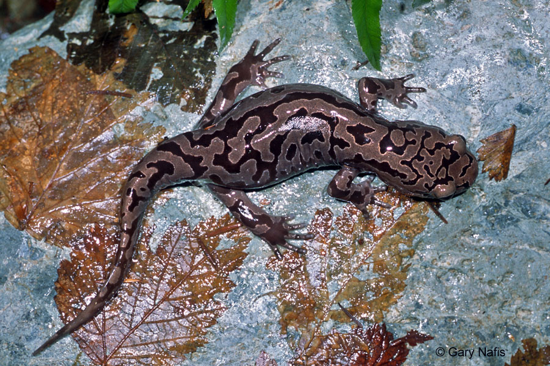

*Young salamander surveying a crunchy landscape: wet leaves on a creek rock. (Credit: Gary Nafis)*

### *Methods*

The data utilized for this analysis was collected annually throughout both Clear Cut and Old Growth sections of Mack Creek. The same 150m were sampled throughout the 24 year period, and Pacific Giant Salamander abundance, length and weight were recorded. Utilizing this data we conducted analyses to better understand differences in salamander size and abundance in relation to habitat variations throughout the creek. We performed exploratory data visualization, chi squared analysis, a two sample t-test, one-way ANOVA and post-hoc Tukey test. A significance level of *a*=0.05 was used as a cutoff. All analyses were performed using R 3. 6. 1.

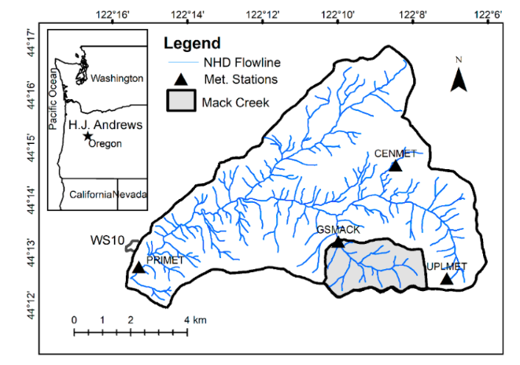

*Map of Mack Creek located within H.J. Andrews Experimental Forest in Western Oregon. (Credit: Mosquera et al. 2018.)*

#### *Results A:*

Annual salamander abundance is displayed from 1993-2017, highlighting the comparison of sections of the creek in clear cut and old growth portions of forest (Figure 1). While there is slight variability, there is no clear difference in salamander abundance between clear cut and old growth forest. In general, abundance appears to have increased during the time period of study.

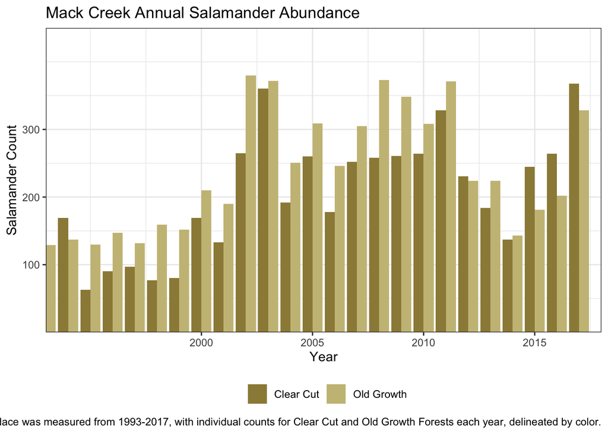

#### *Results B & C:*

We evaluated the relationship between channel classification (Cascades, Pool and Side-Channel) and salamander abundance in both Old Growth and Clear Cut forest sections. While there are not clear trends between forest sections, the largest proportion of salamanders were found in Cascades, with Side-Channel and Pool creek sections following respectively. We conducted a chi squared analysis to determine if this relationship was statistically significant, and we did not find sufficient evidence to reject the null hypothesis that forest condition and channel classification are independent ($\chi$<sup>2</sup>(2) = 5.54, *p* = 0.06).

**Table 1.** *Measuring 2017 salamander abundance relative to forest section, channel classification. Proportional abundance for Clear Cut and Old Growth forests are shown in parentheses to delineate channel. Chi-squared analysis detmerined this relationship to be statistically insignificant* *p* = 0.06)

| 2017 Salamander Counts by Channel Classification in Old Growth and Clear Cut Sections of Mack Creek Creek Section | 2017 Salamander Counts by Channel Classification in Old Growth and Clear Cut Sections of Mack Creek Cascades | 2017 Salamander Counts by Channel Classification in Old Growth and Clear Cut Sections of Mack Creek Pool | 2017 Salamander Counts by Channel Classification in Old Growth and Clear Cut Sections of Mack Creek Side-channel |
| --- | --- | --- | --- |
| Clear Cut | 247 (67%) | 31 (8%) | 90 (24%) |
| Old Growth | 201 (63%) | 45 (14%) | 74 (23%) |

#### *Results D:*

By analyzing the weights of Giant Pacific Salamanders in Old Growth and Clear Cut sections of Mack Creek we calculated mean salamander weights of 7.8 grams in Clear Cut areas, and 6.6 grams in Old Growth areas. The P-Value of 0.09 led us to conclude that the two means are not significantly different from one another. However, Salamanders measured in clear cut forests are 18% heavier, on average, than their old growth counterparts. This remains a notable change, even as it does not meet statistical significance.

#### *Results E:*

All three of these channels have notable outliers in which heavy salamanders could skew the means.The median weight of salamanders across channels may be a more representative measurement of sampled areas.

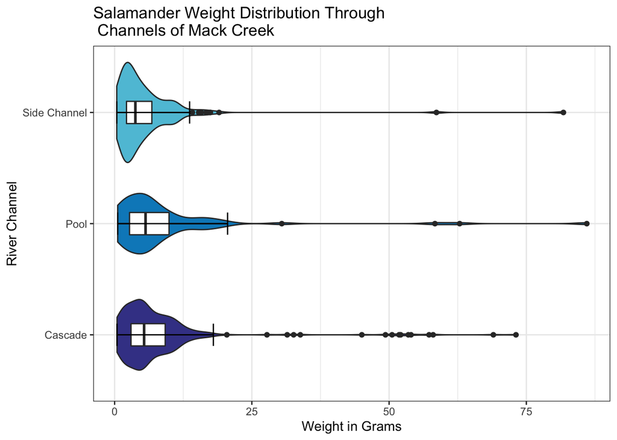

### *Citations:*

Bolsinger, Charles L., and Karen L. Waddell. “Area of Old-Growth Forests in California, Oregon, and Washington.” *United States Department of Agriculture*, 1993, doi:10.2737/pnw-rb-197.

Gregory S. V. 2016. Aquatic Vertebrate Population Study in Mack Creek, Andrews Experimental Forest, 1987 to present. *Environmental Data Initiative.* https://doi.org/10.6073/pasta/5de64af9c11579266ef20da2ff32f702. Dataset accessed 11/19/2019

Mosquera, Giovanny M., Segura, Catalina, and Patricio Crespo. “Flow Partitioning Using High-Resolution Isotopic and Electrical Conductivity Data.” *Water.* 2018, https://doi.org/10.3390/w10070904